# Assignment 1

Group 67: Jamie Faber, Laurens Prast, Amal Salman

27 February 2022

## Imports

```r
library(ggplot2)
library(car)
```

## Exercise 3

### a)

```r
fruitflies=read.table(file="fruitflies.txt",header=TRUE)
# add loglongevity column
fruitflies$loglongevity <- log(fruitflies$longevity)
fruitflies
```

| thorax | longevity | activity | loglongevity |
| --- | --- | --- | --- |
| 0.64 | 40 | isolated | 3.6889 |
| 0.70 | 37 | isolated | 3.6109 |
| 0.72 | 44 | isolated | 3.7842 |
| 0.72 | 47 | isolated | 3.8501 |
| 0.72 | 47 | isolated | 3.8501 |
| 0.76 | 47 | isolated | 3.8501 |
| 0.78 | 68 | isolated | 4.2195 |
| 0.80 | 47 | isolated | 3.8501 |
| 0.84 | 54 | isolated | 3.9890 |
| 0.84 | 61 | isolated | 4.1109 |

[output cut: 65 more lines]

**Informative plot of the data:**

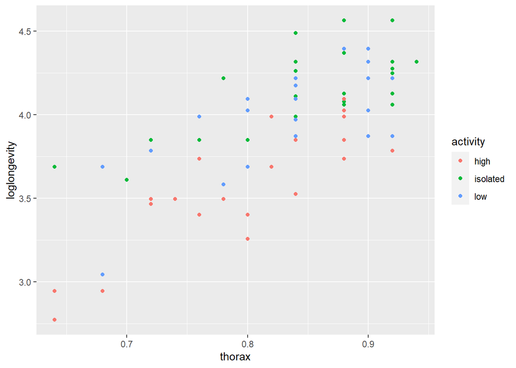

```r
ggplot(fruitflies) +
  geom_point(aes(x=thorax, y=loglongevity, color=activity))
```

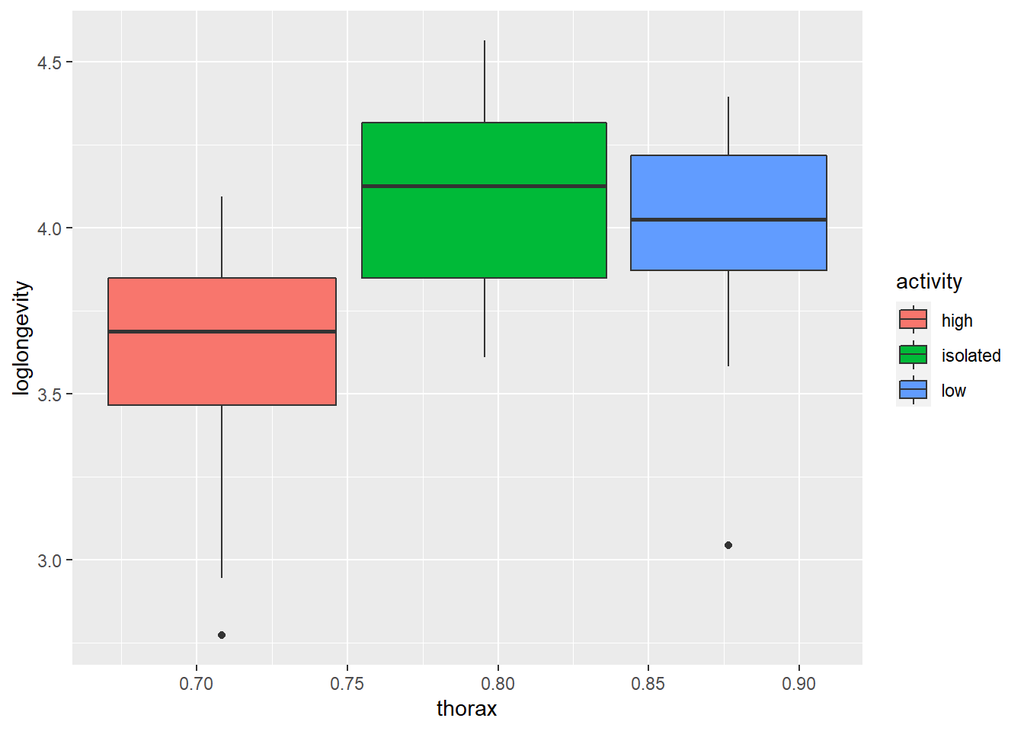

```r
ggplot(fruitflies) +
  geom_boxplot(aes(x = thorax, y=loglongevity, fill = activity))
```

**One-way Anova:**

```r
aov=lm(loglongevity~activity,data=fruitflies)
anova(aov)
```

|  | Df | Sum Sq | Mean Sq | F value | Pr(>F) |
| --- | --- | --- | --- | --- | --- |
| activity | 2 | 3.6665 | 1.833247 | 19.421 | 1.7977e-07 |
| Residuals | 72 | 6.7966 | 0.094397 | NA | NA |

p-value < 0.05 so there is significant differences between the activity groups, i.e., activity influences longevity.

Checking assumptions:

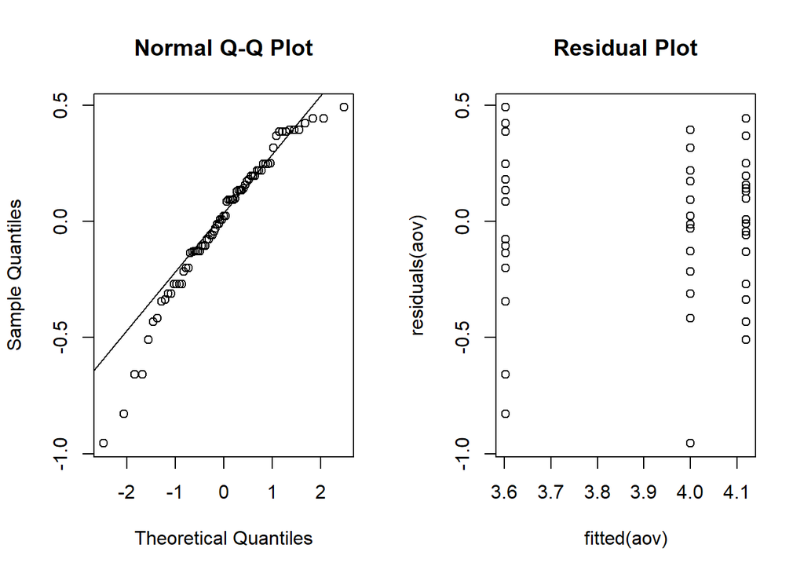

```r
par(mfrow=c(1,2))
qqnorm(residuals(aov)); qqline(residuals(aov))
plot(fitted(aov),residuals(aov), main = "Residual Plot")
```

```r
leveneTest(loglongevity~activity,data=fruitflies)
```

|  | Df | F value | Pr(>F) |
| --- | --- | --- | --- |
| group | 2 | 0.81621 | 0.44615 |
|  | 72 | NA | NA |

```r
shapiro.test(residuals(aov))
```

```
##
##  Shapiro-Wilk normality test
##
## data:  residuals(aov)
## W = 0.954, p-value = 0.0087
```

Levene’s test passed, Shapiro didn’t.

From the plots and tests, the assumption of equal variances is met, but we cannot assume normality, therefore the requirements for the one-way Anova test aren’t met.

Therefore, need to use Kruskal-Wallis test instead.

**Kruskal-Wallis:**

```r
kruskal.test(loglongevity~activity,data=fruitflies)
```

```
##
##  Kruskal-Wallis rank sum test
##
## data:  loglongevity by activity
## Kruskal-Wallis chi-squared = 27.4, df = 2, p-value = 1.1e-06
```

However, Kruskal-Wallis test comes at the same conclusion as the one-way Anova test: p-value < 0.05 so there is significant differences between the activity groups, i.e., activity influences longevity.

**Estimated longevities for the three conditions:**

```r
summary(aov)
```

```
##
## Call:
## lm(formula = loglongevity ~ activity, data = fruitflies)
##
## Residuals:
##     Min      1Q  Median      3Q     Max
## -0.9553 -0.1334  0.0255  0.2089  0.4922
##
## Coefficients:
##                  Estimate Std. Error t value Pr(>|t|)
## (Intercept)        3.6021     0.0614   58.62  < 2e-16 ***
## activityisolated   0.5172     0.0869    5.95  8.8e-08 ***
## activitylow        0.3977     0.0869    4.58  1.9e-05 ***
## ---
## Signif. codes:  0 '***' 0.001 '**' 0.01 '*' 0.05 '.' 0.1 ' ' 1
##
## Residual standard error: 0.307 on 72 degrees of freedom
## Multiple R-squared:  0.35,   Adjusted R-squared:  0.332
## F-statistic: 19.4 on 2 and 72 DF,  p-value: 1.8e-07
```

The high activity group has an estimated 3.60 longevity, while the isolated activity group has 0.52+3.6, and the low activity group has 0.40 + 3.6. This indicates that the lower the sexual activity, the longer the longevity is as can be seen in the calculation beneth here.

```r
high <- 3.6021;high
```

```
## [1] 3.6021
```

```r
isolated <- high+0.5172;isolated
```

```
## [1] 4.1193
```

```r
low <- high+0.3977;low
```

```
## [1] 3.9998
```

### b)

**ANCOVA test:**

```r
fruitflies$activity=as.factor(fruitflies$activity)
fruitflies1=lm(loglongevity~thorax+activity,data=fruitflies)
fruitflies2=lm(loglongevity~thorax,data=fruitflies)
anova(fruitflies2,fruitflies1)
```

|  | Res.Df | RSS | Df | Sum of Sq | F | Pr(>F) |
| --- | --- | --- | --- | --- | --- | --- |
| 1 | 73 | 5.0309 | NA | NA | NA | NA |
| 2 | 71 | 2.9180 | 2 | 2.1129 | 25.705 | 4e-09 |

p-value < 0.05 so again activity has a significant influence on longevity (now considering thorax but not the interaction between thorax and activity).

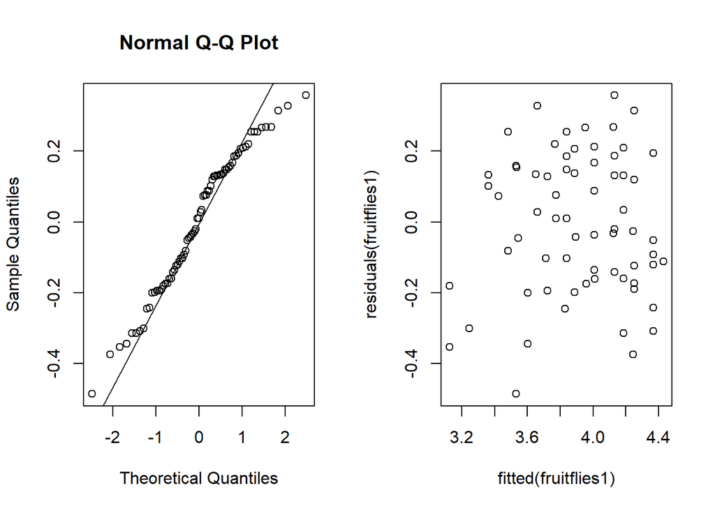

```r
par(mfrow=c(1,2))
qqnorm(residuals(fruitflies1)); qqline(residuals(fruitflies1))
plot(fitted(fruitflies1),residuals(fruitflies1))
```

```r
shapiro.test(residuals(fruitflies1))
```

```
##
##  Shapiro-Wilk normality test
##
## data:  residuals(fruitflies1)
## W = 0.968, p-value = 0.057
```

Passed the normality test so meets all assumptions for ANCOVA.

```r
summary(fruitflies1)
```

```
##
## Call:
## lm(formula = loglongevity ~ thorax + activity, data = fruitflies)
##
## Residuals:
##     Min      1Q  Median      3Q     Max
## -0.4858 -0.1612  0.0104  0.1510  0.3574
##
## Coefficients:
##                  Estimate Std. Error t value Pr(>|t|)
## (Intercept)        1.2189     0.2486    4.90  5.8e-06 ***
## thorax             2.9790     0.3067    9.71  1.1e-14 ***
## activityisolated   0.4100     0.0584    7.02  1.1e-09 ***
## activitylow        0.2857     0.0585    4.88  6.2e-06 ***
## ---
## Signif. codes:  0 '***' 0.001 '**' 0.01 '*' 0.05 '.' 0.1 ' ' 1
##
## Residual standard error: 0.203 on 71 degrees of freedom
## Multiple R-squared:  0.721,  Adjusted R-squared:  0.709
## F-statistic: 61.2 on 3 and 71 DF,  p-value: <2e-16
```

```r
max_thorax = max(fruitflies$thorax)
min_thorax = min(fruitflies$thorax)

predict(fruitflies1,data.frame(thorax = min_thorax, activity = "high"), interval = "confidence")
```

```
##      fit    lwr    upr
## 1 3.1255 2.9986 3.2524
```

```r
predict(fruitflies1,data.frame(thorax = min_thorax, activity = "isolated"), interval = "confidence")
```

```
##      fit    lwr  upr
## 1 3.5355 3.3909 3.68
```

```r
predict(fruitflies1,data.frame(thorax = min_thorax, activity = "low"), interval = "confidence")
```

```
##      fit    lwr    upr
## 1 3.4112 3.2658 3.5566
```

```r
predict(fruitflies1,data.frame(thorax = max_thorax, activity = "high"), interval = "confidence")
```

```
##      fit    lwr    upr
## 1 4.0192 3.9014 4.1369
```

```r
predict(fruitflies1,data.frame(thorax = max_thorax, activity = "isolated"), interval = "confidence")
```

```
##      fit    lwr   upr
## 1 4.4292 4.3263 4.532
```

```r
predict(fruitflies1,data.frame(thorax = max_thorax, activity = "low"), interval = "confidence")
```

```
##      fit    lwr    upr
## 1 4.3049 4.2026 4.4071
```

Hierboven is voor log longetivity. Hier beneden voor longetivity!

```r
max_thorax = max(fruitflies$thorax)
min_thorax = min(fruitflies$thorax)
fruitflies3 =lm(longevity~thorax+activity,data=fruitflies)

predict(fruitflies3,data.frame(thorax = min_thorax, activity = "high"), interval = "confidence")
```

```
##      fit    lwr    upr
## 1 17.501 10.993 24.009
```

```r
predict(fruitflies3,data.frame(thorax = min_thorax, activity = "isolated"), interval = "confidence")
```

```
##      fit    lwr   upr
## 1 37.567 30.154 44.98
```

```r
predict(fruitflies3,data.frame(thorax = min_thorax, activity = "low"), interval = "confidence")
```

```
##      fit  lwr    upr
## 1 30.555 23.1 38.009
```

```r
predict(fruitflies3,data.frame(thorax = max_thorax, activity = "high"), interval = "confidence")
```

```
##      fit    lwr    upr
## 1 57.287 51.249 63.324
```

```r
predict(fruitflies3,data.frame(thorax = max_thorax, activity = "isolated"), interval = "confidence")
```

```
##      fit    lwr    upr
## 1 77.352 72.078 82.627
```

```r
predict(fruitflies3,data.frame(thorax = max_thorax, activity = "low"), interval = "confidence")
```

```
##     fit    lwr    upr
## 1 70.34 65.097 75.584
```

What are the estimated longevities for the three groups, for flies with the minimal and maximal thorax lengths?

For flies with minimal thorax: high: 17.5, isolated: 37.6, low: 30.6

For flies with maximal thorax: high: 57.3, isolated: 77.4, low: 70.3

### c)

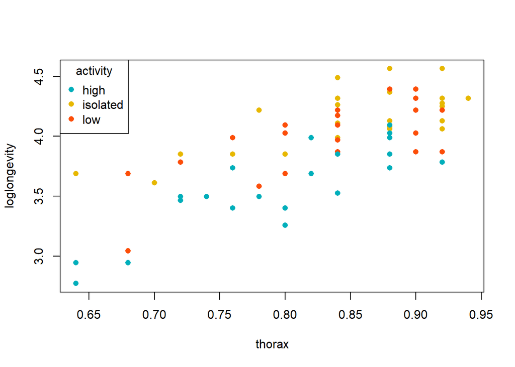

```r
colors <- c("#00AFBB", "#E7B800", "#FC4E07")
colors <- colors[as.numeric(fruitflies$activity)]

plot(loglongevity~thorax, col=colors, pch=16, data=fruitflies)
legend("topleft", legend = levels(fruitflies$activity),
      col = c("#00AFBB", "#E7B800", "#FC4E07"), pch = 16, title="activity")
```

*whether this dependence is similar under all three conditions of sexual activity.*

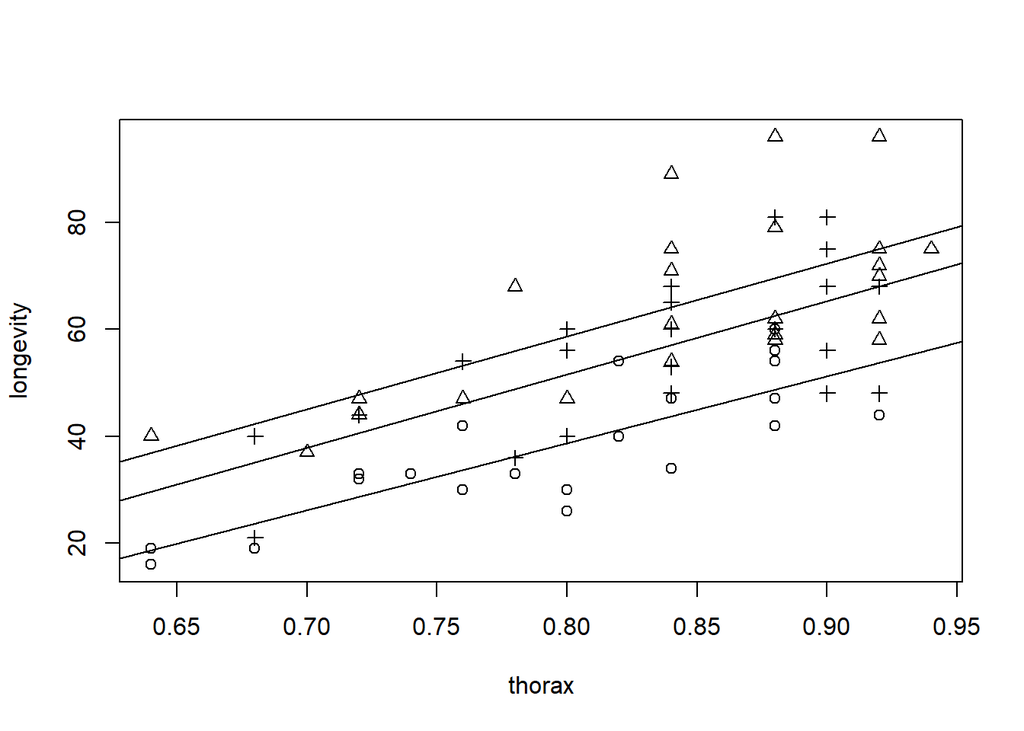

```r
plot(longevity~thorax,pch=unclass(activity), data=fruitflies)
for (i in c("high", "isolated", "low"))  abline(lm(longevity~thorax,data=fruitflies[fruitflies$activity==i,]))
```

Plot shows no indication that the true lines would not be parallel.

```r
fruitflies3=lm(loglongevity~activity*thorax,data=fruitflies)
anova(fruitflies3)
```

|  | Df | Sum Sq | Mean Sq | F value | Pr(>F) |
| --- | --- | --- | --- | --- | --- |
| activity | 2 | 3.66649 | 1.833247 | 45.7687 | 2.2280e-13 |
| thorax | 1 | 3.87860 | 3.878596 | 96.8327 | 9.0196e-15 |
| activity:thorax | 2 | 0.15421 | 0.077107 | 1.9251 | 1.5362e-01 |
| Residuals | 69 | 2.76377 | 0.040055 | NA | NA |

p-value=0.15 >0.05 so there is no interaction between factor activity and predictor thorax.

```r
summary(fruitflies3)
```

```
##
## Call:
## lm(formula = loglongevity ~ activity * thorax, data = fruitflies)
##
## Residuals:
##     Min      1Q  Median      3Q     Max
## -0.4980 -0.1592 -0.0003  0.1462  0.3598
##
## Coefficients:
##                         Estimate Std. Error t value Pr(>|t|)
## (Intercept)                0.598      0.419    1.43    0.158
## activityisolated           1.546      0.584    2.65    0.010 *
## activitylow                0.972      0.642    1.51    0.135
## thorax                     3.755      0.522    7.20  5.8e-10 ***
## activityisolated:thorax   -1.393      0.712   -1.96    0.055 .
## activitylow:thorax        -0.854      0.779   -1.10    0.277
## ---
## Signif. codes:  0 '***' 0.001 '**' 0.01 '*' 0.05 '.' 0.1 ' ' 1
##
## Residual standard error: 0.2 on 69 degrees of freedom
## Multiple R-squared:  0.736,  Adjusted R-squared:  0.717
## F-statistic: 38.4 on 5 and 69 DF,  p-value: <2e-16
```

activityisolated:thorax & activitylow:thorax p-value > 0.05, again confirming that there is no interaction/dependence between activity and thorax.

### d)

By including thorax length in the analysis, we found out that thorax also significantly influences longevity, and the higher the thorax length, the longer the longevity. So I prefer the analysis with thorax length because it gives a more comprehensive analysis of influences in longevity.

### e)

```r
fruitflies$activity=as.factor(fruitflies$activity)
fruitflies1=lm(longevity~thorax+activity,data=fruitflies)
fruitflies2=lm(longevity~thorax,data=fruitflies)
anova(fruitflies2,fruitflies1)
```

|  | Res.Df | RSS | Df | Sum of Sq | F | Pr(>F) |
| --- | --- | --- | --- | --- | --- | --- |
| 1 | 73 | 12640 | NA | NA | NA | NA |
| 2 | 71 | 7673 | 2 | 4966.7 | 22.979 | 2.0163e-08 |

p-value still < 0.05

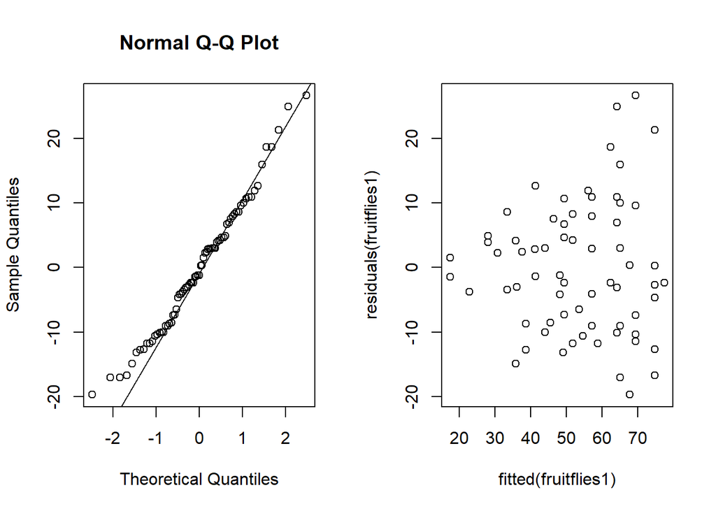

```r
par(mfrow=c(1,2))
qqnorm(residuals(fruitflies1)); qqline(residuals(fruitflies1))
plot(fitted(fruitflies1),residuals(fruitflies1))
```

```r
shapiro.test(residuals(fruitflies1))
```

```
##
##  Shapiro-Wilk normality test
##
## data:  residuals(fruitflies1)
## W = 0.981, p-value = 0.32
```

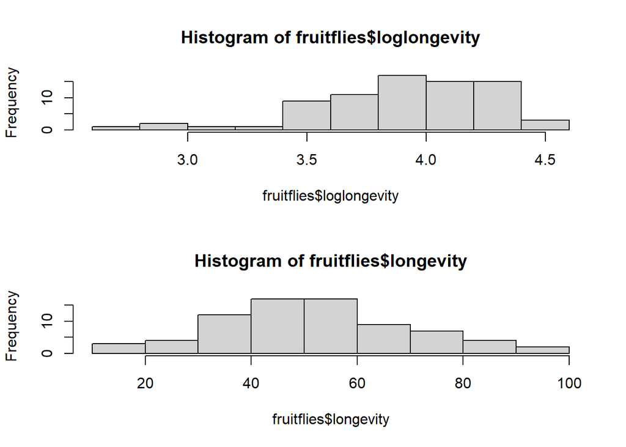

```r
par(mfrow=c(2,1))
hist(fruitflies$loglongevity)
hist(fruitflies$longevity)
```

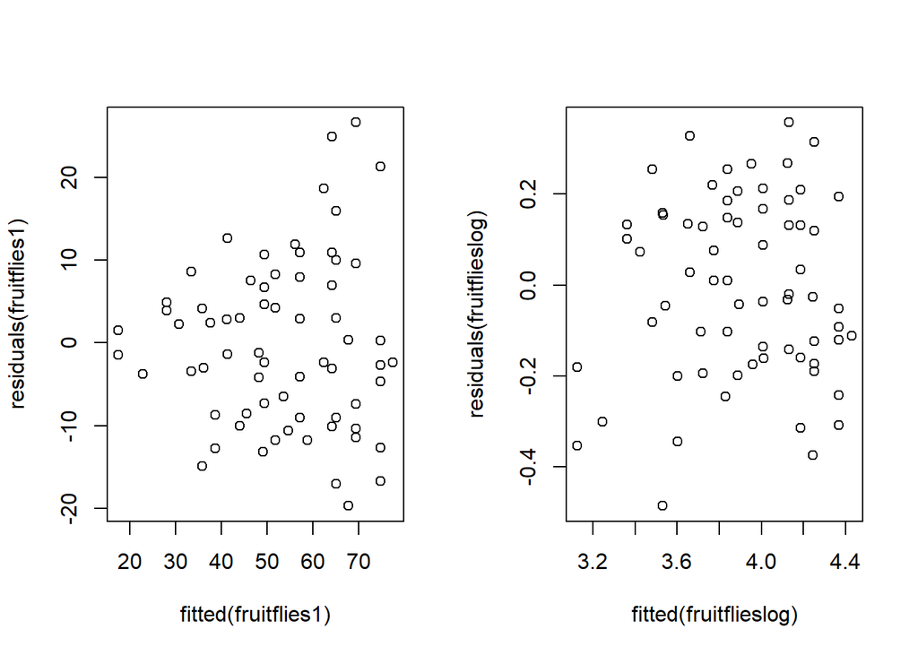

```r
par(mfrow=c(1,2))
fruitflies1=lm(longevity~thorax+activity,data=fruitflies)
plot(fitted(fruitflies1),residuals(fruitflies1))
fruitflieslog=lm(loglongevity~thorax+activity,data=fruitflies)
plot(fitted(fruitflieslog),residuals(fruitflieslog))
```

The histograms and the Shapiro tests confirm that longevity is more normal than loglongevity, and since the ANCOVA analysis relies on normality, it was not wise to use the logarithm as response.

However the fitted residuals plots show the loglongevity have a beter spread, more homogeneity than the longevity plot